# Analisis de Ruido

Mateo Espinal Londoño - Karen Sofia Fajardo Pantoja - Nicolas David Piñeros Pulido - Clara Isabel Sierra Echeverry - Maria de los Angeles Garcia Estrada

# Introduccion

El ruido es un tipo de sonido que puede llegar a ser desagradable y perjudicial, es capaz de generar problemas de estrés, ansiedad, depresión y afecciones, como la pérdida de audición. En este trabajo se realizará un análisis del sonido en los alrededores del campus, para ver a que niveles puede llegar el ruido generado, analizaremos si el ruido está dentro de los limites permitidos y daremos algunas alternativas para disminuirlo.

## Objetivos

- Estimar el nivel del ruido en la periferia de la Universidad y ver como es la contaminación auditiva
- Observar como los factores externos influyen en la contaminación auditiva en la zona asignada y proporcionar alternativas para disminuir el ruido

## Metodologia

- Se dividió la zona asignada en regiones de 5x5 metros.
- Se tomó las muestras de ruido con la aplicación “Science Journal” instalada en los celulares de cada integrante.
- A cada integrante se le asignó diferentes cuadrantes de la zona.
- Se tomaron 5 veces las muestras de toda la zona, generando de esta manera 5 replicas por cuadrante y con una duración de 5 minutos.
- Lo anterior se realizó en las siguientes jornadas:
- Mañana [8:00-10:00]
- Medio Dia [11:00-13:00]
- Tarde [16:00-18:00]

### Zona a la cual se le analizo el muestreo

A continuacion se puede observar el mapa del terrono en el que se realizo el muestreo

[figure not shown]

### Fotografia del terreno estudiado

En este podemos observar un par de fotografias mas detalladas de el estado del terreno que ese uso para realizar el muestreo de ruido.

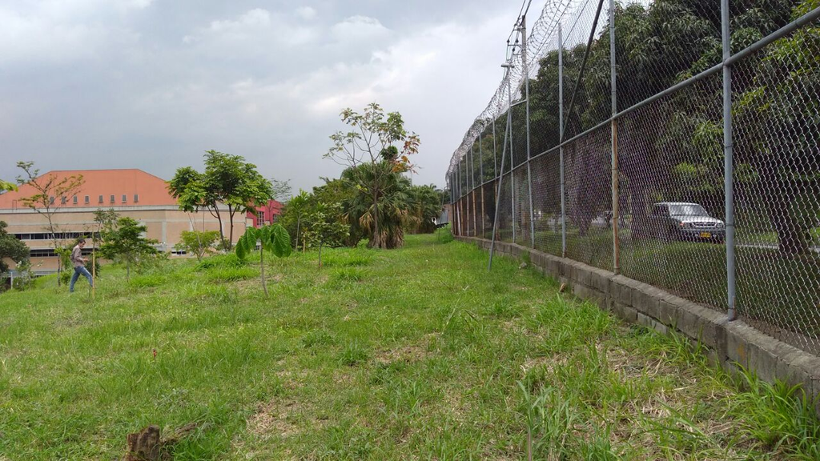

.

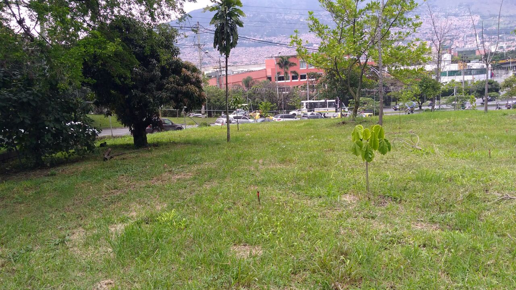

## Analisis

Al informarnos Sobre los niveles de ruido permitido en colombia encontramos la siguiente tabla en la pagina de [Secretaria de ambiente de bogota](http://ambientebogota.gov.co/ruido):

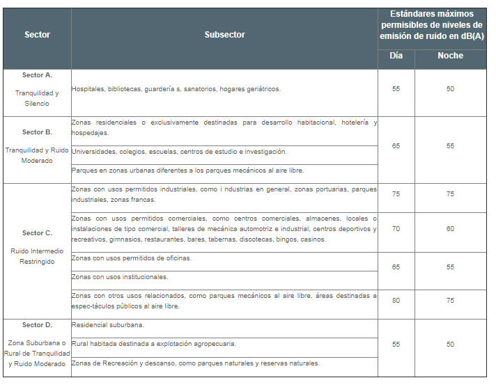

De la cual nos interesa la informacion del sector B en el cual se encuentran las universidades,colegios,escuelas y centros de investigacion, de esta tabla se puede notar que los estandares maximos de ruido en decibeles en la jornada de la mañana es de 65 dB, mientras en la noche es de 55dB.

Basados en esta informacion podemos realizar el analisis de la siguiente grafica.

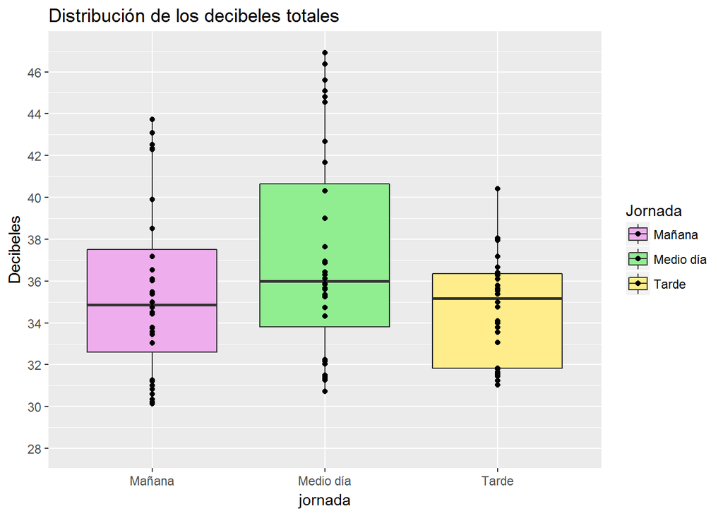

Con esta grafica podemos observar como esta la distribucion del ruido en el sector asignado en las 3 diferentes jornadas,ademas de que se puede apreciar que la mayor dispersion de los datos de ruido se encuentra en la jornada de medio dia, esto se puede deberse a que ese es un horario de gran afluencia vehicular, pero en algunos momentos es demasiado silencioso.

Ademas tambien podemos notar que la mediana en las 3 jornadas es muy similar ya que esta no esta a una diferencia mayor a 3 decibeles, lo que quiere decir que en promedio el ruido es muy similar, y cumple con la norma ya que esta cantidad de decibeles es menor a la de la tabla presentada anteriormente.

Ahora analizaremos el ruido dividiendo el sector asignado en 3 secciones:

- Sector de la Malla
- Sector Central
- Sector Interno

Por lo cual iniciaremos por el sector de la malla con la siguiente grafica.

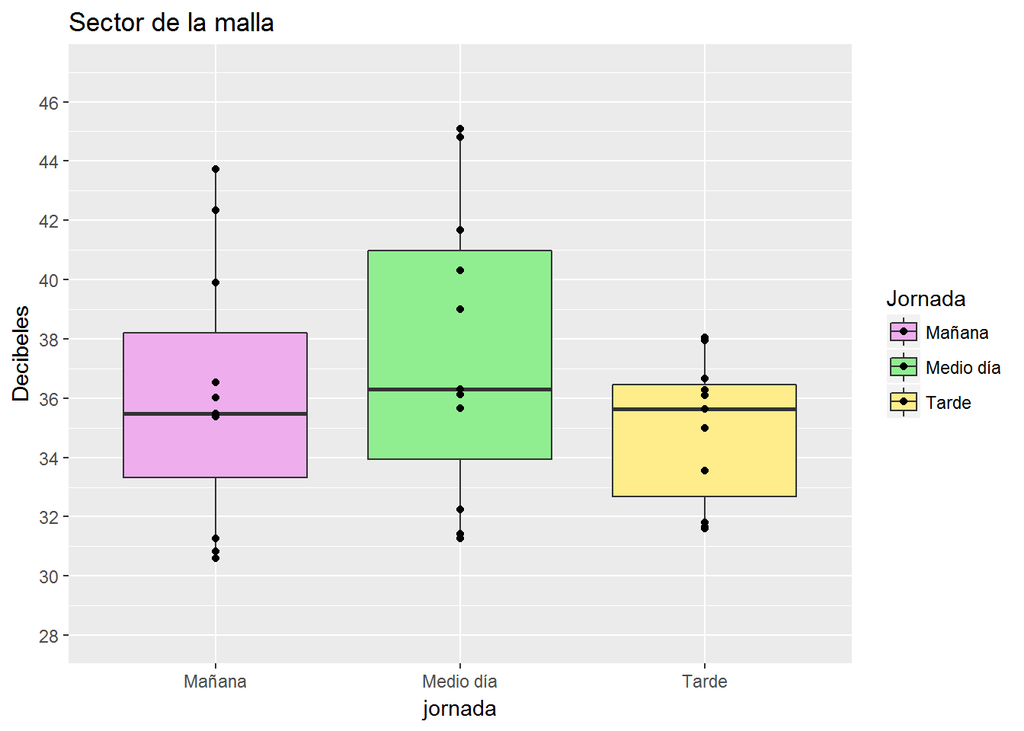

En esta podemos observar que las medianas de las 3 jornadas estan alrededor de los 36dB,que en comparacion con la grafica anterior es un poco mas alto,ademas que podemos notar que en la jornada de el medio dia es en la que se presenta mayor dispersion del ruido, seguido de la mañana y por ultimo la tarde.

Basados en estas observaciones,llegamos a la conclusión que esto se puede dar porque hay una via muy concurrida al lado de la malla, y el mayor flujo de vehiculos transitan en este horario.

Tambien observamos que en la mañana se registraron unos promedios de sonido muy bajos y esto puede deberse a que en esos momentos de la mañana el fluyo vehicular no es tan alto a pesar de tener al lado una via tan concurrida.

Continuaremos con el sector central:

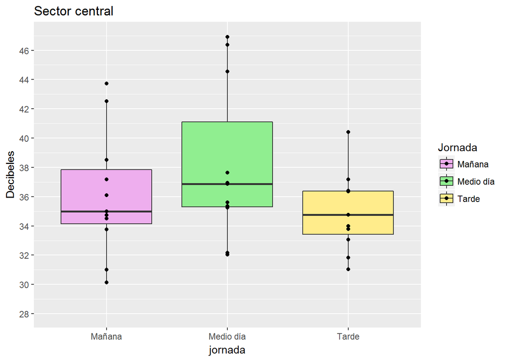

A medida que nos alejamos de la via podemos observar que los decibeles promedio bajan un poco en comparacion con la malla, pero en este caso se puede notar algo muy especial, dado que en la grafica se observa que la mediana de medio dia es mas alta que la de las demas jornadas, en este caso eso se puede deber a que por el sector transitan aviones y helicopteros, por lo cual estos pueden afectar el ruido y aumentar la dispersion, y por lo genereal el mayor transito de este tipo de vehiculos es en esa jornada.

Ademas podemos notar tambien que en la jornada de la tarde la dispersion es mas baja y con respecto a la grafica anterior, su mediana esta mucho mas ajustada en el centro del rango intercuartil, e incluso aunque en esta jornada los datos no esten tan dispersos como la en las anteriores, se puede notar que su dato maximo es inferior a las otras jornadas.

Con esto se puede mostrar que al encontrarse mas hacia el centro del territorio asignado en general el promedio de ruido es menor, aunque ocurran algunos casos atipicos como el de la jornada de la tarde.

Continuaremos con el sector Interior:

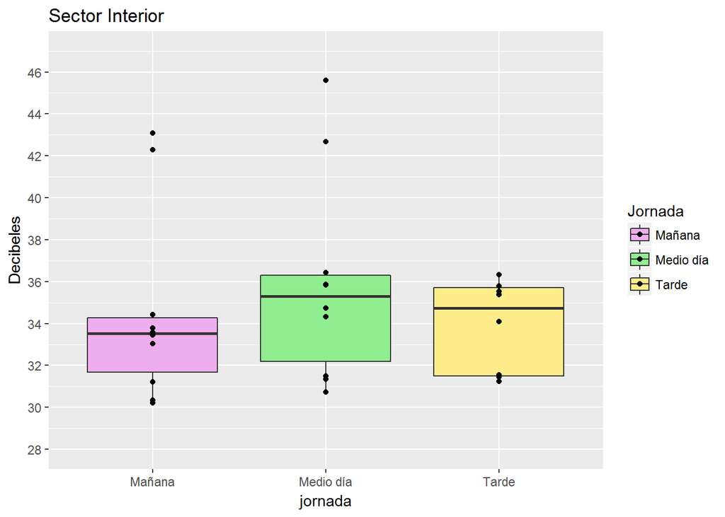

Tambien podemos notar que en las jornadas del dia y del medio dia hay unos datos atipicos muy altos, estos se pueden deber a que en esos momentos paso un avion, un vehiculo de emergencia, o se genero un pequeño trancon lo cual ocasiono que el nivel de ruido fuera mayor a el presentado por la mayoria de los datos en esta seccion.

Dejando de lado un poco las graficas podremos observar el siguiente resumen de la toma en general de las muestras :

### Resumen General decibeles

```
##    Min. 1st Qu.  Median    Mean 3rd Qu.    Max.
##   8.875  31.047  33.671  36.399  38.368  96.794
```

De acuerdo a lo que podemos observar en este resumen el nivel maximo de decibeles permitido se supero en almenos una ocacion dado que con lo mencionado anteriormenete la norma indica que debe se maximo 65dB y el maximo registrado que tenemos es de 96.7dB.

Tambien podemos observar algo muy curioso que no muestran las graficas, como lo es la cantidad minima de decibeles , dado que el minimo registro es de 8.87dB y este valor es muy pequeño para una zona de trafico tan concurrido como lo es la 65 , pero esto se puede deber a que es esos momentos se tomo el dato en un momento muy silencioso, o incluso en un cuadrante alejado del trafico y ademas un momento silecioso.

De acuerdo a media y mediana podemos obsevar que son muy similares y concuerdan con lo mostrado en las graficas, ademas de estar en el nivel percibido.

### Resumen decibeles en la jornada de la mañana

```
##    Min. 1st Qu.  Median    Mean 3rd Qu.    Max.
##   29.29   31.41   33.76   35.72   36.11   53.30
```

En esta jornada podemos obsevar que se obtuvo un minimo de ruido similar a lo esperado dado que es de casi 30dbB , ademas el nivel maximo de ruido registrado en esta jornada es de 53.30 lo cual es menor al maximo permitido por la norma, ademas de ser muy bueno ya que el exceso de ruido es perjudicial.

### Resumen decibeles en la jornada del medio día

```
##    Min. 1st Qu.  Median    Mean 3rd Qu.    Max.
##   25.20   32.56   35.43   37.39   39.08   52.68
```

Por su parte en esta jornada se presenta algo muy similar a la anterior solo que en esta jornada el minimo es mas bajo que el de la jornada de la mañana siendo este de 25.2dB, la unica diferecia notoria se ve mediante la siguiente desviacion estandar:

```
## [1] 7.150009
```

con este valor podemos notar que hay una gran dispersion de los datos, esto concuerda con lo observado en la graficas anteriormente mencionadas , dado que en esta jornada hay un mayor flujo vehicular en general que en las demas jornadas.

### Resumen decibeles en la jornada de la tarde

```
##    Min. 1st Qu.  Median    Mean 3rd Qu.    Max.
##   21.72   31.70   33.29   34.75   36.39   54.19
```

Por ultimo en esta jornada podemos notar que es la que tiene el nivel mas bajo de decibeles tomados en promedio por replica con un valor de 21.72, ademas de que en esta jornada era muy poco comun que se generara un exceso de ruido muy grande, ya que en este horario apenas iniciaba la hora pico y no era muy comun ver tanto trafico atascado.

Ademas podemos decir que en esta jornada de acuerdo a las graficas y el resumen es en donde se presenta la menor dispersion de ruido y al parecer esto puede ser generado por un trafico muy fluido y que en este horario es muy poco comun el paso de aviones y camiones de carga pesada, en comparacion con otras jornadas del dia.

Por ultimo pudimos notar que en caso de nuestra zona asignada esta tenia muy poca cantidad de arboles, por lo cual no se pudo notar si habia mucha diferencia o influencia de estos en el resultado obtenido,aunque podria haber sido un factor muy interesante analizar.

### Alternativa de disminucion de ruido

- Una alternativa que se podria plantear es una mayor plantacion de arboles en la zona para que estos realizen una barrera natura que pueda reducir un poco el ruido ya que esta zona es al aire libre.
- Otra seria colocar una especie de muros forrados de vegetacion en las zonas de la malla, ya que se ha mostrado que estas pueden llegar a reducir el ruido generado por el trafico.

A continuacion se muestra una imagen de ejemplo del forrado:

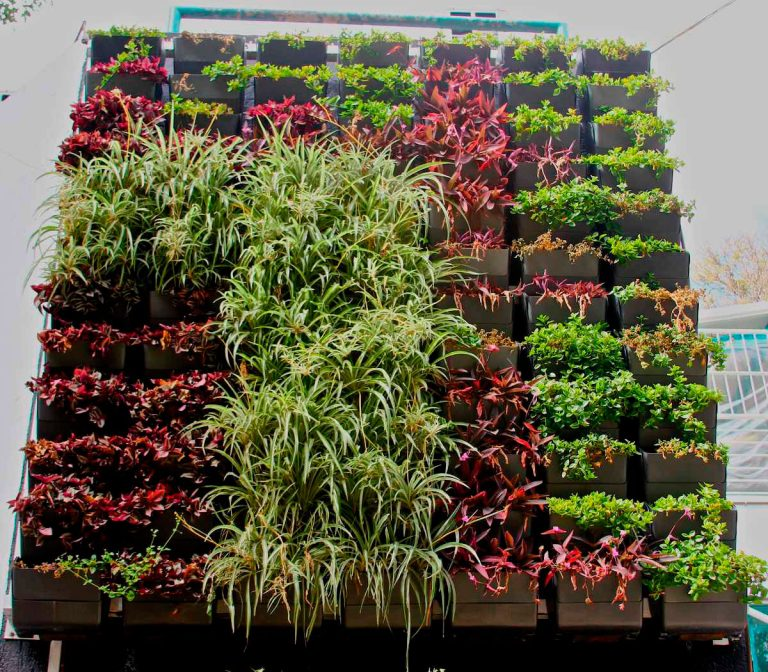

### Referencias

- Niveles de ruido permitido en medellin (similar a el de bogota): https://www.medellin.gov.co/normograma/docs/resolucion_minambientevdt_0627_2006.htm
- Imagen de muros de vegetacion http://www.teorema.com.mx/sostenibilidad/iniciativaprivada/muros-verdes/